# Milestone Report: Exploratory Analysis of the SwiftKey Dataset

Kosntantinos Koumoundouros

## Introduction - Data

This Milestone Report is part of the Data Science Specialization Capstone provided by John Hopkins University /coursera.

The purpose of the Milestone Report is to provide all the steps that took place for Data Cleansing and simple Tokenization of the Swiftkey dataset for English language UTF-8.

Dataset provided -downloaded from coursera Coursera-SwiftKey.zip. Coursera-SwiftKey.zip includes four folders, for different languages, with txt files inside. In our case we are interesting only for English.

Before we load data, we can see from **Code_Chunk_1** in Appendix, the size of three files:

| en_US.blogs.txt | en_US.news.txt | en_US.twitter.txt |
| --- | --- | --- |
| 200.4242 MB | 196.2775 MB | 159.3641 MB |

## Loading, Sampling and Storing Data

### Loading

After exctraction of zip file in working space we can load our three files.

```r
## Reading three source txt files
blogs <- readLines('data_source/en_US.blogs.txt', encoding = 'UTF-8')
news <- readLines('data_source/en_US.news.txt', encoding = 'UTF-8')
twitter <- readLines('data_source/en_US.twitter.txt', encoding = 'UTF-8')
```

Number of lines for each file:

```
##          File   Lines
## 1   blogs.txt  899288
## 2    news.txt 1010242
## 3 twitter.txt 2360148
```

### Sampling and Storing Data

Because of large amount of data i make sample files and i store them for the next step (corpus creating).

```r
## Using rbinom() for creating sampling and save new sample txt files
set.seed(1986)
size <- 1000

blogs <- blogs[rbinom(size, length(blogs), 0.5)]
news <- news[rbinom(size, length(news), 0.5)]
twitter <- twitter[rbinom(size, length(twitter), 0.5)]

## Store files in a sample repo
writeLines(blogs, con = 'data_source/sample/blogs.txt', sep = "\n", useBytes = FALSE)
writeLines(news, con = 'data_source/sample/news.txt', sep = "\n", useBytes = FALSE)
writeLines(twitter, con = 'data_source/sample/twitter.txt', sep = "\n", useBytes = FALSE)

## remove objects
rm(blogs, news, twitter, size)
```

### Corpus Creation from Sample Files

Create Corpus from sample repo and store it with `tm()` packet

```r
library(tm)

## Create Corpus
reposample <- 'data_source/sample'

corpus <- VCorpus(DirSource(reposample, pattern = '.txt', encoding = 'UTF-8'),
                   readerControl = list(language = 'en'))


## Save corpus and remove objects
save(corpus, file = 'data_source/corpus.RData')
rm(reposample, corpus)
```

## Data Preprocessing and Cleansing

In this step all crusal processing for cleansing take place. Data cleansing is nessecary for better Tokenization and modeling. As we can see from below plot, the simple tokenization is not correct because words with no “mean” are used (words with numbers, punctuation, stopwords etc.)

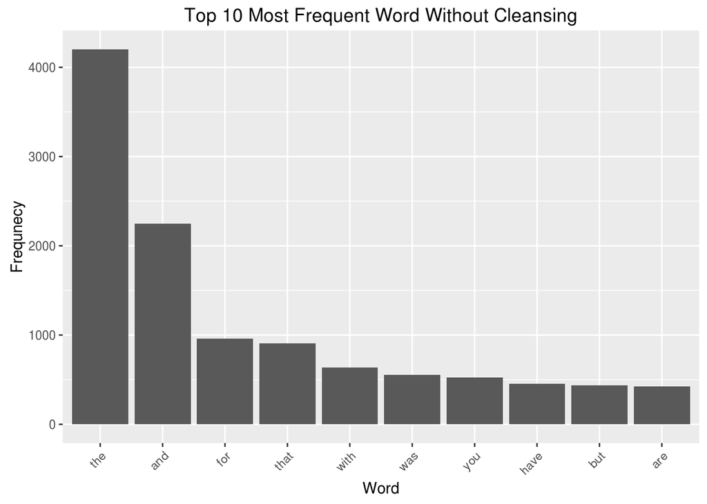

After all neseecary process (data cleansing) the plot is very different (more information about cleansing **Code_Chunk_3**):

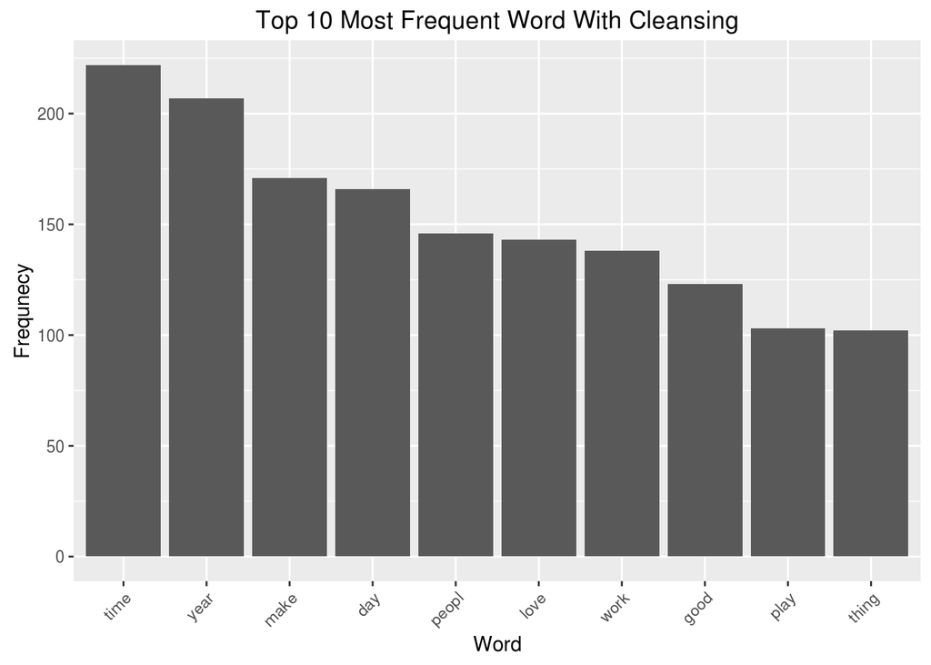

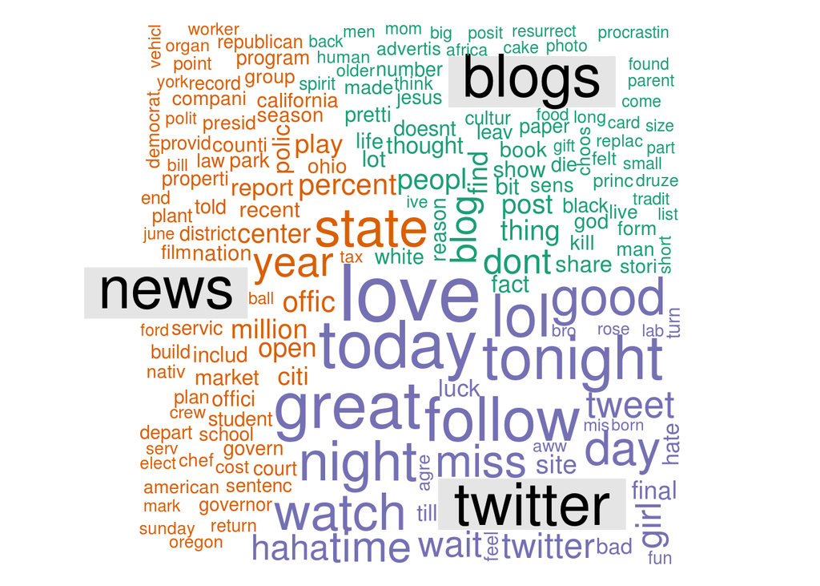

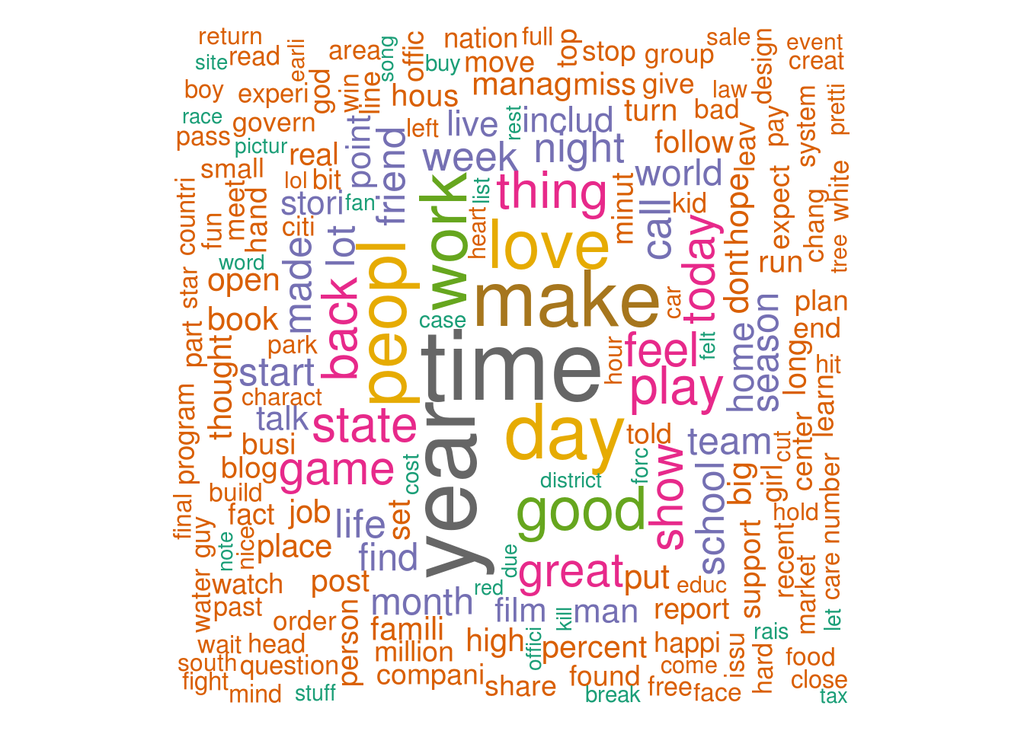

## Simple Tokenization

Bellow we can see a simple view of tokeniziton in three cases, One Word, Two Words and Three Words

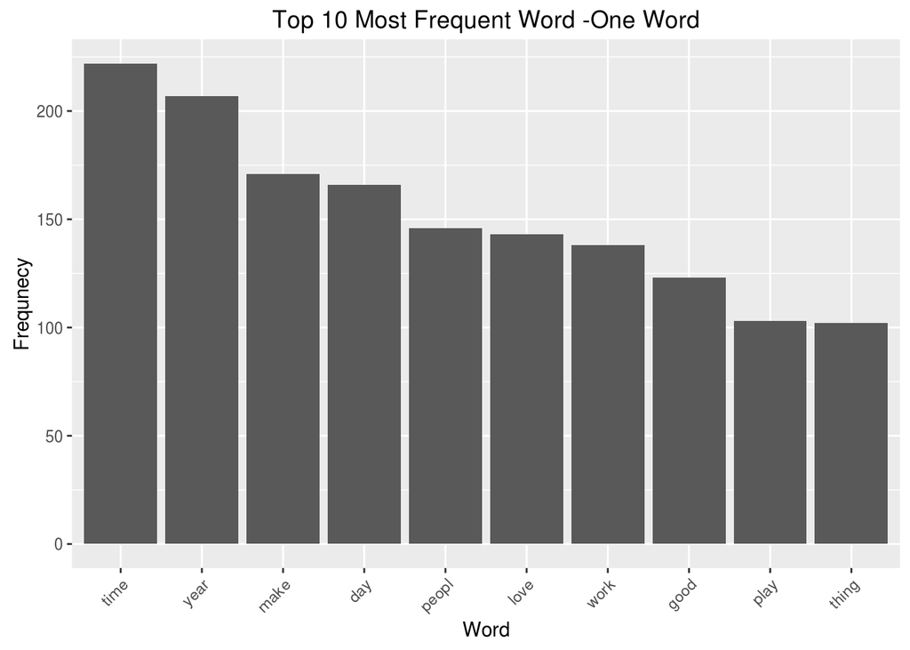

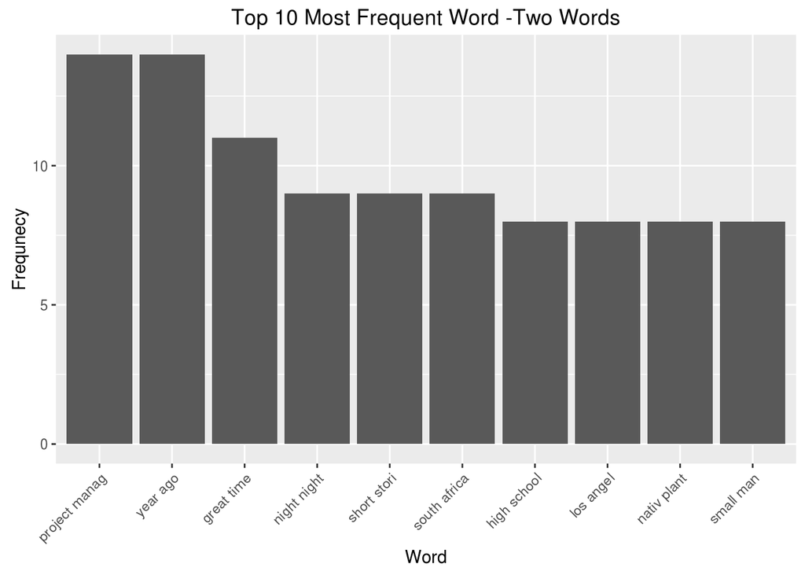

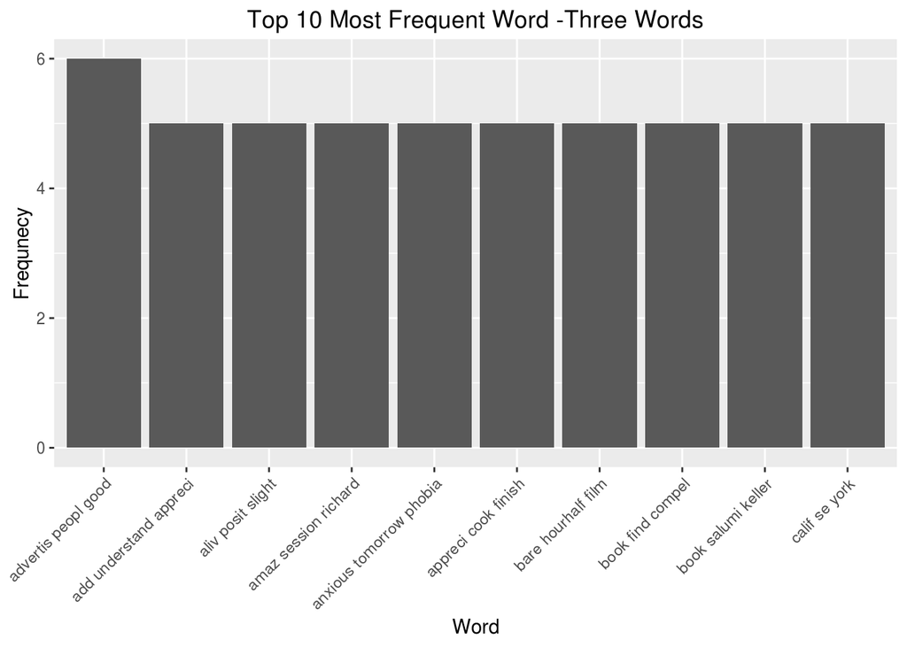

## Further steps

- More reading in Therory of NLP -ngrams.
- Better automated data cleansing of corpus.
- Code optimazation for better time processing.

## Appendix

**Code_Chunk_1**

```r
## File size (in MegaBytes/MB)
file.info('data_source/en_US.blogs.txt')$size   / 1024^2
file.info('data_source/en_US.news.txt')$size    / 1024^2
file.info('data_source/en_US.twitter.txt')$size / 1024^2
```

**Code_Chunk_2**

```r
## Number of lines
length <- as.data.frame(matrix(ncol = 2))
length <- rbind(length, c('blogs.txt', length(blogs)))
length <- rbind(length, c('news.txt', length(news)))
length <- rbind(length, c('twitter.txt', length(twitter)))
names(length) <- c('File', 'Lines')
length <- length[-1,]
rownames(length) <- NULL
```

**Code_Chunk_3**

```r
library(tm)
library(SnowballC)
library(RWeka)


## Load Corpus
load('data_source/corpus.RData')


## Load profanity.csv and make custom functions for data cleansing
# https://github.com/shutterstock/List-of-Dirty-Naughty-Obscene-and-Otherwise-Bad-Words/
profanity <- readLines('data_source/profanity.csv', encoding = 'UTF-8')
nonASCII <- function(x) iconv(x, 'latin1', 'ASCII', '')
removeURL <- function(x) gsub('www[[:alnum:]]*.*|htt[[:alnum:]]*.*', '', x)


## Processing
corpus <- tm_map(corpus, content_transformer(tolower))
corpus <- tm_map(corpus, content_transformer(nonASCII))
corpus <- tm_map(corpus, content_transformer(removeURL))
corpus <- tm_map(corpus, removeWords, stopwords('SMART'))
corpus <- tm_map(corpus, removePunctuation)
corpus <- tm_map(corpus, removeNumbers)
corpus <- tm_map(corpus, removeWords, stopwords('en'))
corpus <- tm_map(corpus, removeWords, profanity)
corpus <- tm_map(corpus, stripWhitespace)
corpus <- tm_map(corpus, stemDocument)

rm(profanity, nonASCII, removeURL)


## Stage the Data
dtm <- DocumentTermMatrix(corpus)
tdm <- TermDocumentMatrix(corpus)
```

**Code_Chunk_4**

```r
## Count frequency of worlds
freq <- colSums(as.matrix(dtm))
wordCount <- data.frame(word = names(freq), freq = freq)
wordCount <- wordCount[order(wordCount$freq, decreasing=TRUE),]
rownames(wordCount) <- NULL
rm(freq)
library('ggplot2')

top10 <- head(wordCount, 10)

p <- ggplot(top10, aes(reorder(word, -freq), freq))
p <- p + geom_bar(stat = 'identity')
p <- p + xlab('Word')
p <- p + ylab('Frequnecy')
p <- p + ggtitle('Top 10 Most Frequent Word With Cleansing')
p <- p + theme(axis.text.x=element_text(angle=45, hjust=1))


## More plotes after cleansing, -Simple word comparison (from three txt files) by frequence
library('wordcloud')
comparison <- as.matrix(tdm)
colnames(comparison) <- c('blogs', 'news', 'twitter')
comparison.cloud(comparison,max.words=300,random.order=FALSE)

### -Word Cloud by frequence
library('wordcloud')
comparison <- as.matrix(tdm)
colnames(comparison) <- c('blogs', 'news', 'twitter')
comparison.cloud(comparison,max.words=300,random.order=FALSE)

cloud_temp <- as.matrix(tdm)
cloud_temp1 <- sort(rowSums(cloud_temp), decreasing = TRUE)
cloud_temp2 <- data.frame(word = names(cloud_temp1), freq = cloud_temp1)
set.seed(1986)
wordcloud(words = cloud_temp2$word, freq = cloud_temp2$freq, min.freq = 1,
          max.words=300, random.order = FALSE, rot.per = 0.35,
          colors = brewer.pal(8, 'Dark2'))
```

**Code_Chunk_5**

```r
## One Word
Tokenizer  <- function(x)
                NGramTokenizer(x, Weka_control(min = 1, max = 1))


Token1 <- DocumentTermMatrix(Corpus(VectorSource(corpus)),
                             control = list(weighting = weightTf,
                                            tokenize = Tokenizer))

## Two Words
Tokenizer  <- function(x)
        NGramTokenizer(x, Weka_control(min = 2, max = 2))

Token2 <- DocumentTermMatrix(Corpus(VectorSource(corpus)),
                             control = list(weighting = weightTf,
                                            tokenize = Tokenizer))
## Three Words
Tokenizer  <- function(x)
        NGramTokenizer(x, Weka_control(min = 3, max = 3))

Token3 <- DocumentTermMatrix(Corpus(VectorSource(corpus)),
                             control = list(weighting = weightTf,
                                            tokenize = Tokenizer))
## Data Frame One Word
freq1 <-  colSums(as.matrix(Token1))
one_word <- data.frame(word = names(freq1), freq = freq1)
one_word <- one_word[order(one_word$freq, decreasing=TRUE),]
rownames(one_word) <- NULL
rm(freq1)

## Data Frame Two Words
freq2 <-  colSums(as.matrix(Token2))
two_word <- data.frame(word = names(freq2), freq = freq2)
two_word <- two_word[order(two_word$freq, decreasing=TRUE),]
rownames(two_word) <- NULL
rm(freq2)

## Data Frame Three Words
freq3 <-  colSums(as.matrix(Token3))
three_word <- data.frame(word = names(freq3), freq = freq3)
three_word <- three_word[order(three_word$freq, decreasing=TRUE),]
rownames(three_word) <- NULL
rm(freq3)

## Top10 One Word and Plot
top10 <- head(one_word, 10)

p1 <- ggplot(top10, aes(reorder(word, -freq), freq))
p1 <- p1 + geom_bar(stat = 'identity')
p1 <- p1 + xlab('Word')
p1 <- p1 + ylab('Frequnecy')
p1 <- p1 + ggtitle('Top 10 Most Frequent Word -One Word')
p1 <- p1 + theme(axis.text.x=element_text(angle=45, hjust=1))
p1

## Top10 Two Words and Plot
top10 <- head(two_word, 10)
p2 <- ggplot(top10, aes(reorder(word, -freq), freq))
p2 <- p2 + geom_bar(stat = 'identity')
p2 <- p2 + xlab('Word')
p2 <- p2 + ylab('Frequnecy')
p2 <- p2 + ggtitle('Top 10 Most Frequent Word -Two Words')
p2 <- p2 + theme(axis.text.x=element_text(angle=45, hjust=1))
p2

## Top10 Three Words and Plot
top10 <- head(three_word, 10)
p3 <- ggplot(top10, aes(reorder(word, -freq), freq))
p3 <- p3 + geom_bar(stat = 'identity')
p3 <- p3 + xlab('Word')
p3 <- p3 + ylab('Frequnecy')
p3 <- p3 + ggtitle('Top 10 Most Frequent Word -Three Words')
p3 <- p3 + theme(axis.text.x=element_text(angle=45, hjust=1))
p3
```